# Digitized Legal Compendium

Authors

Jesse Lecy, ASU

Teresa Harrison, Drexel

Published

December 19, 2024

# Combine State Files

## Stacked Files

|  | Unnamed: 0.1 | Unnamed: 0 | STATE | Regulatory Type | Regulatory Type Full | Regulatory Body | Regulation Indicator | Notes | Year legislation originally enacted | Year legislation changed | Type of Change | Section Code | State | division | section | text | ID-State | ID | Regulatory Type Abbr | section original | 0 | 1 | Section Code Re | section1 | first_element |
| --- | --- | --- | --- | --- | --- | --- | --- | --- | --- | --- | --- | --- | --- | --- | --- | --- | --- | --- | --- | --- | --- | --- | --- | --- | --- |
| 1 | 0 | 0 | Alabama | STATE | STATE | NA | Alabama | Alabama | NA | NA | NA | NA | NA | NA | NA | NA | id-al-000 | id-0 | NA | NA | NA | NA | NA | NA | NA |
| 2 | 1 | 1 | Alabama | Bifurcated | Bifurcated | NA | No | No Alabama Code § 13A-9-70 et seq. | NA | NA | NA | 13A-9-70 | NA | NA | NA | NA | id-al-001 | id-1 | BF | NA | NA | NA | NA | NA | NA |
| 3 | 2 | 2 | Alabama | Registration Office | Registration Office | NA | NA | Office of the Alabama Attorney General (Consumer Protection Division) http://www.ago.state.al.us/Page-Consumer-Protection-Consumer-Charities | NA | NA | NA | NA | NA | NA | NA | NA | id-al-002 | id-2 | RE | NA | NA | NA | NA | NA | NA |
| 4 | 3 | 3 | Alabama | Sale of Assets | Sale of Assets - AG | AG | No | No | NA | NA | NA | NA | NA | NA | NA | NA | id-al-003 | id-3 | SA | NA | NA | NA | NA | NA | NA |
| 5 | 4 | 4 | Alabama | Sale of Assets | Sale of Assets - Other | Other | No | No | NA | NA | NA | NA | NA | NA | NA | NA | id-al-004 | id-4 | SA | NA | NA | NA | NA | NA | NA |
| 6 | 5 | 5 | Alabama | Mergers | Mergers - AG | AG | No | No | NA | NA | NA | NA | NA | NA | NA | NA | id-al-005 | id-5 | MG | NA | NA | NA | NA | NA | NA |

## Rename Variables

| V1 | V2 |
| --- | --- |
| Unnamed: 0.1 | id1 |
| Unnamed: 0 | id2 |
| ID-State | id3 |
| ID | id4 |
| STATE | state |
| Regulation Indicator | reg_indicator |
| Regulatory Type | reg_rule_label |
| Regulatory Type Abbr | reg_rule_abbr |
| Regulatory Type Full | type_body_combined |
| Regulatory Body | reg_body_label |
| State | code_state |
| division | code_division |
| Section Code | code_section1 |
| section | code_section2 |
| text | code_text |
| Year legislation originally enacted | code_year_enacted |
| Year legislation changed | code_change_year |
| Type of Change | code_change_type |
| Notes | notes |
| section original | section_original |
| 0 | v0 |
| 1 | v1 |
| Section Code Re | section_code_re |
| section1 | section1 |
| first_element | first_element |

|  | id1 | id2 | id3 | id4 | state | reg_indicator | reg_rule_label | reg_rule_abbr | type_body_combined | reg_body_label | code_state | code_division | code_section1 | code_section2 | code_text | code_year_enacted | code_change_year | code_change_type | notes | section_original | v0 | v1 | section_code_re | section1 | first_element |
| --- | --- | --- | --- | --- | --- | --- | --- | --- | --- | --- | --- | --- | --- | --- | --- | --- | --- | --- | --- | --- | --- | --- | --- | --- | --- |
| 1 | 0 | 0 | id-al-000 | id-0 | Alabama | Alabama | STATE | NA | STATE | NA | NA | NA | NA | NA | NA | NA | NA | NA | Alabama | NA | NA | NA | NA | NA | NA |
| 2 | 1 | 1 | id-al-001 | id-1 | Alabama | No | Bifurcated | BF | Bifurcated | NA | NA | NA | 13A-9-70 | NA | NA | NA | NA | NA | No Alabama Code § 13A-9-70 et seq. | NA | NA | NA | NA | NA | NA |
| 3 | 2 | 2 | id-al-002 | id-2 | Alabama | NA | Registration Office | RE | Registration Office | NA | NA | NA | NA | NA | NA | NA | NA | NA | Office of the Alabama Attorney General (Consumer Protection Division) http://www.ago.state.al.us/Page-Consumer-Protection-Consumer-Charities | NA | NA | NA | NA | NA | NA |
| 4 | 3 | 3 | id-al-003 | id-3 | Alabama | No | Sale of Assets | SA | Sale of Assets - AG | AG | NA | NA | NA | NA | NA | NA | NA | NA | No | NA | NA | NA | NA | NA | NA |
| 5 | 4 | 4 | id-al-004 | id-4 | Alabama | No | Sale of Assets | SA | Sale of Assets - Other | Other | NA | NA | NA | NA | NA | NA | NA | NA | No | NA | NA | NA | NA | NA | NA |
| 6 | 5 | 5 | id-al-005 | id-5 | Alabama | No | Mergers | MG | Mergers - AG | AG | NA | NA | NA | NA | NA | NA | NA | NA | No | NA | NA | NA | NA | NA | NA |

## Fix Encodings

When data is copied from websites or PDFs, saved in Excel, and later exported to CSV the encodings get messed up. The input text had “double mojibake” problems, meaning the encodings were mangled at least twice, usually once from copying from HTML and a second with how Excel stores text. It was especially the case with the “symbol” character used to denote statute numbers in legal citations.

These steps here ensure the text in the final dataset has a simple, standardized encoding so that text fields will not be mangled if read into stats programs.

**Problematic cases look like this:**

```
"\"(4) �\u0080\u009cpaid solicitor�\u0080\u009d means a person who is r
equired to be registered under AS 45.68.010(b), and includes a person who
is employed, procured, or engaged, directly or indirectly, by a paid
solicitor to solicit, if the person is compensated; �\u0080\u009cpaid
solicitor�\u0080\u009d does not include\n          (A) an attorney l
icensed to practice law in this or another state, an investment counselor,
an insurance company, or a supervised financial institution, to the extent
the attorney, investment counselor, insurance company, or supervised
financial institution advises the person on whether to make a contribution;
or\n\n          (B) a bona fide salaried officer, employee, or volunteer of
a charitable organization;\" AS 45.68.900"
```

**Fixed:**

“(4)”paid solicitor” means a person who is required to be registered under AS 45.68.010(b), and includes a person who is employed, procured, or engaged, directly or indirectly, by a paid solicitor to solicit, if the person is compensated; “paid solicitor” does not include (A) an attorney licensed to practice law in this or another state, an investment counselor, an insurance company, or a supervised financial institution, to the extent the attorney, investment counselor, insurance company, or supervised financial institution advises the person on whether to make a contribution; or (B) a bona fide salaried officer, employee, or volunteer of a charitable organization;” AS 45.68.900

## Add Legal Compendium Fields

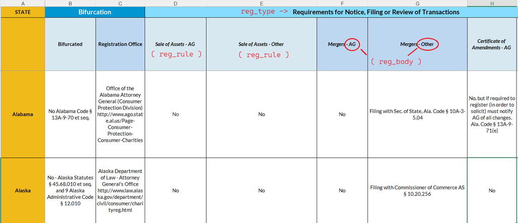

**REGULATION TYPE (GROUP)**

| reg_type | reg_type_label |
| --- | --- |
| DISSOLV | Notice or Action for Dissolutions |
| AUDITFI | Audits |
| BIFURCD | Bifurcation of charitable regulatory body |
| REPORTS | Notice, Filing or Review of Transactions |
| ORGTYPE | Exemptions from Registering for Specific Organization Types |
| REMEDYT | Defined remedies |
| FNDRAZE | Oversight of professional fundraisers |
| HOSPCON | Notice, Oversight or Filing of Hospital Conversions |
| REGILAW | Registration Law |

**REGULATORY RULE**

| reg_rule | reg_rule_label |
| --- | --- |
| ADMINI | Administrative Dissolutions |
| THRESH | Audit Threshold |
| BIFURC | Bifurcated Regulatory Structure |
| AMMEND | Certificate of Amendments |
| CTRUST | Charitable Trusts |
| DISSOL | Dissolution |
| VENTUR | Does the state oversee commercial-coventuring (e.g. by requiring that the co-venture be registered or by requiring that the charitable organization files the co-venture contract)? |
| CNTRCT | Does the state require a copy of any contract between a charitable organization and a commercial fundraiser or fundraising counsel be filed with the regulator? |
| FINANC | Does the state require annual financial reporting by charitable organizations in addition to filing a copy of the 990 with the regulator (if filing 990 is required)? |
| ANNUAL | Does the state require annual financial reporting by commercial fundraisers? |

[output cut: 30 more lines]

**REGULATORY ACTION**

| reg_rule | reg_action | reg_action_label |
| --- | --- | --- |
| ADMINI | REQMNT | requirement |
| THRESH | REQMNT | requirement |
| BIFURC | REQMNT | requirement |
| AMMEND | REQMNT | requirement |
| CTRUST | EXMPTN | exemption |
| DISSOL | REMEDY | remedy |
| VENTUR | REQMNT | requirement |
| CNTRCT | REQMNT | requirement |
| FINANC | REQMNT | requirement |
| ANNUAL | REQMNT | requirement |

[output cut: 30 more lines]

|  | reg_rule_abbr | id1 | id2 | id3 | id4 | state | reg_indicator | type_body_combined | reg_body_label | code_state | code_division | code_section1 | code_section2 | code_text | code_year_enacted | code_change_year | code_change_type | notes | section_original | v0 | v1 | section_code_re | section1 | first_element | reg_type | reg_type_label | reg_rule | reg_rule_label | reg_action | … |
| --- | --- | --- | --- | --- | --- | --- | --- | --- | --- | --- | --- | --- | --- | --- | --- | --- | --- | --- | --- | --- | --- | --- | --- | --- | --- | --- | --- | --- | --- | --- |
| 1 | NA | 0 | 0 | id-al-000 | id-0 | Alabama | Alabama | STATE | Not Specific | NA | NA | NA | NA | NA | NA | NA | NA | Alabama | NA | NA | NA | NA | NA | NA | NA | NA | NA | NA | NA | … |
| 2 | BF | 1 | 1 | id-al-001 | id-1 | Alabama | No | Bifurcated | Not Specific | NA | NA | 13A-9-70 | NA | NA | NA | NA | NA | No Alabama Code § 13A-9-70 et seq. | NA | NA | NA | NA | NA | NA | BIFURCD | Bifurcation of charitable regulatory body | BIFURC | Bifurcated Regulatory Structure | REQMNT | … |
| 3 | RE | 2 | 2 | id-al-002 | id-2 | Alabama | NA | Registration Office | Not Specific | NA | NA | NA | NA | NA | NA | NA | NA | Office of the Alabama Attorney General (Consumer Protection Division) http://www.ago.state.al.us/Page-Consumer-Protection-Consumer-Charities | NA | NA | NA | NA | NA | NA | BIFURCD | Bifurcation of charitable regulatory body | REGIOF | Registration Office | REQMNT | … |
| 4 | SA | 3 | 3 | id-al-003 | id-3 | Alabama | No | Sale of Assets - AG | Attorney General | NA | NA | NA | NA | NA | NA | NA | NA | No | NA | NA | NA | NA | NA | NA | REPORTS | Notice, Filing or Review of Transactions | ASSETS | Sale of Assets | REQMNT | … |
| 5 | SA | 4 | 4 | id-al-004 | id-4 | Alabama | No | Sale of Assets - Other | Other | NA | NA | NA | NA | NA | NA | NA | NA | No | NA | NA | NA | NA | NA | NA | REPORTS | Notice, Filing or Review of Transactions | ASSETS | Sale of Assets | REQMNT | … |
| 6 | MG | 5 | 5 | id-al-005 | id-5 | Alabama | No | Mergers - AG | Attorney General | NA | NA | NA | NA | NA | NA | NA | NA | No | NA | NA | NA | NA | NA | NA | REPORTS | Notice, Filing or Review of Transactions | MERGER | Mergers | REQMNT | … |

## Standardize State Names

|  | state | state_abbr |
| --- | --- | --- |
| 1 | Alabama | AL |
| 2 | Alaska | AK |
| 3 | Arizona | AZ |
| 4 | Arkansas | AR |
| 5 | California | CA |
| 6 | Colorado | CO |

## Fix IDs

The new ID format base includes the state, regulation class, regulation type, and the regulatory body. For regulatory body:

- AG: At tourney General
- OT: Other
- NS: Not Specified in the LC Field

```
 [1] "AL-BIFURCD-BIFURC-NS" "AL-BIFURCD-REGIOF-NS" "AL-REPORTS-ASSETS-AG"
 [4] "AL-REPORTS-ASSETS-OT" "AL-REPORTS-MERGER-AG" "AL-REPORTS-MERGER-OT"
 [7] "AL-REPORTS-AMMEND-AG" "AL-REPORTS-AMMEND-OT" "AL-DISSOLV-VOLUNT-AG"
[10] "AL-DISSOLV-VOLUNT-OT"
```

New ID format with some added counts for data quality inspection purposes.

- n_id: number of statutes per reg (rule class + rule + agency)
- n_rule: number of statutes per reg (rule class + rule)
- n_type: number of statutes per reg group (rule class)
- n_state: number of nonprofit statutes within the state (not unique)

| ID | reg_indicator | n_id | n_rule | n_type | n_state |
| --- | --- | --- | --- | --- | --- |
| AL-BIFURCD-BIFURC-NS-001 | No | 1 | 1 | 2 | 42 |
| AL-BIFURCD-REGIOF-NS-001 | NA | 1 | 1 | 2 | 42 |
| AL-REPORTS-ASSETS-AG-001 | No | 1 | 2 | 7 | 42 |
| AL-REPORTS-ASSETS-OT-001 | No | 1 | 2 | 7 | 42 |
| AL-REPORTS-MERGER-AG-001 | No | 1 | 2 | 7 | 42 |
| AL-REPORTS-MERGER-OT-001 | Yes | 1 | 2 | 7 | 42 |
| AL-REPORTS-AMMEND-AG-001 | No | 1 | 2 | 7 | 42 |
| AL-REPORTS-AMMEND-OT-001 | Yes | 1 | 2 | 7 | 42 |
| AL-DISSOLV-VOLUNT-AG-001 | No | 1 | 2 | 4 | 42 |
| AL-DISSOLV-VOLUNT-OT-001 | Yes | 1 | 2 | 4 | 42 |

[output cut: 15 more lines]

Note that we are currently only counting rows that contain any data. It appears that this version includes rows as placeholders (there is one row for each regulatory type, even if there is no statute within the state pertaining to the issue).

The **reg_x** field is a count of those that had some info on the statutes in the notes (notes seemed to be more complete than the statute text field).

```
#  reg_x = 1 if there were notes
#  in that row; 0 otherwise

d$reg_x <- ifelse( is.na(d$notes), 0, 1 )
d$reg_x[ d$notes == "" ] <- 0
```

| ID | reg_x | reg_indicator | n_id |
| --- | --- | --- | --- |
| AL-BIFURCD-BIFURC-NS-001 | 1 | No | 1 |
| AL-BIFURCD-REGIOF-NS-001 | 1 | NA | 1 |
| AL-REPORTS-ASSETS-AG-001 | 1 | No | 1 |
| AL-REPORTS-ASSETS-OT-001 | 1 | No | 1 |
| AL-REPORTS-MERGER-AG-001 | 1 | No | 1 |
| AL-REPORTS-MERGER-OT-001 | 1 | Yes | 1 |
| AL-REPORTS-AMMEND-AG-001 | 1 | No | 1 |
| AL-REPORTS-AMMEND-OT-001 | 1 | Yes | 1 |
| AL-DISSOLV-VOLUNT-AG-001 | 1 | No | 1 |
| AL-DISSOLV-VOLUNT-OT-001 | 1 | Yes | 1 |

[output cut: 15 more lines]

Any case with no statute or notes listed is coded as a count of zero here. That’s different than states where the indicator is reported as “NO” in the spreadsheet (many rows did not include a YES/NO value for the indicator). **We need to double-check this.**

# Fix Data Ecoding Problems

## Example Problem Cases

**Section Numbers Converting to Dates:**

```
§ 7-6-55  -->  7/6/1955
§ 10-3810 -->  10/1/3810
```

**Inconsistent Input in Raw Files:**

| Section Code | State | division | section |
| --- | --- | --- | --- |
| 552.1 | oklahoma | NA | 18-552-1 |
| 552.6 | oklahoma | NA | 18-552-6 |
| 50-22-01(2)(a) | NA | NA | NA |
| 50-22-01(2)(b)(6) | NA | NA | NA |
| 50-22-01(2)(b)(4)) | NA | NA | NA |
| 82.356 | nevada | NA | 82.35600000000001 |
| 617.1420 | florida | NA | 617.1420000000001 |
| 21-19 | nebraska | NA | 21-19-141 |
| 21-1977 | nebraska | NA | 21-1977 |
| 14-3-1041 | georgia | part-4 | 14-3-1041 |
| 14-3-1005 | georgia | part-1 | 14-3-1005 |
| 29-410.03 | district-of-columbia | 29-410-03 | index.html |
| 29-410.01 | district-of-columbia | 29-410-01 | index.html |

## Current Fixes

To preserve statute sections as text and prevent them from being read as dates, a {SS} value is added:

- {SS}: 10A-3-5.04
- {SS}: 13A-9-71(e)
- {SS}: 10A-1-4.02

A universal citation field is created from:

- state_abbr
- code_label: “Code” or alternative name for state statutes
- code_annotated: is the cited text the annotated version?
- code_section: section cited

|  | ID | state | state_abbr | reg_rule_abbr | reg_indicator | reg_x | n_id | n_rule | n_type | n_state | reg_type | reg_type_label | reg_rule | reg_rule_label | reg_action | reg_action_label | reg_body | reg_body_label | code_univ_cite | code_state | code_label | code_annotated | code_division | code_section | code_section1 | code_section2 | code_text | notes | code_year_enacted | … |
| --- | --- | --- | --- | --- | --- | --- | --- | --- | --- | --- | --- | --- | --- | --- | --- | --- | --- | --- | --- | --- | --- | --- | --- | --- | --- | --- | --- | --- | --- | --- |
| 1 | AL-BIFURCD-BIFURC-NS-001 | Alabama | AL | BF | No | 1 | 1 | 1 | 2 | 42 | BIFURCD | Bifurcation of charitable regulatory body | BIFURC | Bifurcated Regulatory Structure | REQMNT | requirement | NS | Not Specific | AL Code § 13A-9-70 | NA | Code | no | NA | {SS}: 13A-9-70 | {SS}: 13A-9-70 |  | NA | No Alabama Code § 13A-9-70 et seq. | NA | … |
| 2 | AL-BIFURCD-REGIOF-NS-001 | Alabama | AL | RE | NA | 1 | 1 | 1 | 2 | 42 | BIFURCD | Bifurcation of charitable regulatory body | REGIOF | Registration Office | REQMNT | requirement | NS | Not Specific |  | NA | Code | no | NA |  |  |  | NA | Office of the Alabama Attorney General (Consumer Protection Division) http://www.ago.state.al.us/Page-Consumer-Protection-Consumer-Charities | NA | … |
| 3 | AL-REPORTS-ASSETS-AG-001 | Alabama | AL | SA | No | 1 | 1 | 2 | 7 | 42 | REPORTS | Notice, Filing or Review of Transactions | ASSETS | Sale of Assets | REQMNT | requirement | AG | Attorney General |  | NA | Code | no | NA |  |  |  | NA | No | NA | … |
| 4 | AL-REPORTS-ASSETS-OT-001 | Alabama | AL | SA | No | 1 | 1 | 2 | 7 | 42 | REPORTS | Notice, Filing or Review of Transactions | ASSETS | Sale of Assets | REQMNT | requirement | OT | Other |  | NA | Code | no | NA |  |  |  | NA | No | NA | … |
| 5 | AL-REPORTS-MERGER-AG-001 | Alabama | AL | MG | No | 1 | 1 | 2 | 7 | 42 | REPORTS | Notice, Filing or Review of Transactions | MERGER | Mergers | REQMNT | requirement | AG | Attorney General |  | NA | Code | no | NA |  |  |  | NA | No | NA | … |
| 6 | AL-REPORTS-MERGER-OT-001 | Alabama | AL | MG | Yes | 1 | 1 | 2 | 7 | 42 | REPORTS | Notice, Filing or Review of Transactions | MERGER | Mergers | REQMNT | requirement | OT | Other | AL Code § 10A-3-5.04 ;; INDEX.HTML | alabama | Code | no | 10A-3-5-04 | {SS}: 10A-3-5.04 ;; INDEX.HTML | {SS}: 10A-3-5.04 | {SS}: INDEX.HTML | Section 10A-3-5.04Articles of merger or consolidation. (a) Upon the approval, articles of merger or articles of consolidation shall be executed for each nonprofit corporation by its president or a vic… | Filing with Sec. of State, Ala. Code § 10A-3-5.04 | NA | … |
| 7 | AL-REPORTS-AMMEND-AG-001 | Alabama | AL | CA | No | 1 | 1 | 2 | 7 | 42 | REPORTS | Notice, Filing or Review of Transactions | AMMEND | Certificate of Amendments | REQMNT | requirement | AG | Attorney General | AL Code § 13A-9-71(e) | NA | Code | no | NA | {SS}: 13A-9-71(e) | {SS}: 13A-9-71(e) |  | NA | No, but if required to register (in order to solicit) must notify AG of all changes. Ala. Code § 13A-9-71(e) | NA | … |
| 8 | AL-REPORTS-AMMEND-OT-001 | Alabama | AL | CA | Yes | 1 | 1 | 2 | 7 | 42 | REPORTS | Notice, Filing or Review of Transactions | AMMEND | Certificate of Amendments | REQMNT | requirement | OT | Other | AL Code § 10A-1-4.02 | NA | Code | no | NA | {SS}: 10A-1-4.02 | {SS}: 10A-1-4.02 |  | NA | If the name of the entity is altered, must file with the judge of probate and with the Sec. of State, Ala. Code § 10A-1-4.02; Restated Certificate of Formation filed with judge of probate, Ala. Code S… | NA | … |
| 9 | AL-DISSOLV-VOLUNT-AG-001 | Alabama | AL | VD | No | 1 | 1 | 2 | 4 | 42 | DISSOLV | Notice or Action for Dissolutions | VOLUNT | Voluntary Dissolutions | REQMNT | requirement | AG | Attorney General |  | NA | Code | no | NA |  |  |  | NA | No | NA | … |
| 10 | AL-DISSOLV-VOLUNT-OT-001 | Alabama | AL | VD | Yes | 1 | 1 | 2 | 4 | 42 | DISSOLV | Notice or Action for Dissolutions | VOLUNT | Voluntary Dissolutions | REQMNT | requirement | OT | Other | AL Code § 10A-3-7.06 ;; INDEX.HTML | alabama | Code | no | 10A-3-7-06 | {SS}: 10A-3-7.06 ;; INDEX.HTML | {SS}: 10A-3-7.06 | {SS}: INDEX.HTML | Section 10A-3-7.06 Voluntary dissolution - Filing of articles of dissolution. (a) The articles of dissolution and two copies thereof shall be delivered to the judge of probate. If the judge of probate… | Probate court and Sec. of State, Ala. Code § 10A-3-7.06 | NA | … |

## Save Combined Dataset

```r
readr::write_excel_csv( d, "02-data-inter/ALL-STATES-FORMATTED.CSV", na="" )
```

# Summary Stats

## Recreate Legal Compendium

| state_abbr | ADMINI | AMMEND | ANNUAL | ASSETS | AUDITS | BIFURC | BONDNG | BRDRMV | CNTRCT | COMREG | CONGRE | COUNSL | CTRUST | DDONOR | DISSOL | EDUCAT | FINANC | FNDNOS | FNDYES | GOVMNT | HOSPIT | JUDICI | MEMFRA | MERGER | NONSOL | OTHTYP | POLITI | PTOEDU | REGIOF | … |
| --- | --- | --- | --- | --- | --- | --- | --- | --- | --- | --- | --- | --- | --- | --- | --- | --- | --- | --- | --- | --- | --- | --- | --- | --- | --- | --- | --- | --- | --- | --- |
| AK | No , Yes | No , Yes | Yes | No | No | No | Yes | Yes | Yes | Yes | No | No | No | Yes | Yes | No | Yes | No | No | No | No | No , Yes | No | No , Yes | Yes | Yes | Yes | No | NA | … |
| AL | NULL | No , Yes | Yes | No | No | No | Yes | Yes | Yes | Yes | No | Yes | No | Yes | Yes | Yes | No | No | No | No | No | Yes | Yes | No , Yes | Yes | Yes | Yes | No | NA | … |
| AR | No , Yes | No , Yes | Yes | No | Yes | Yes | Yes | Yes | Yes | Yes | No | Yes | No | Yes | Yes | Yes | No | No | No | Yes | Yes | Yes | No | No , Yes | Yes | NULL | Yes | Yes | Secretary of State | … |
| AZ | No , Yes | No , Yes | NULL | No | No | Yes | NULL | Yes | NULL | NULL | NULL | NULL | NULL | NULL | Yes | NULL | NULL | NULL | NULL | NULL | NULL | Yes | NULL | No , Yes | NULL | NULL | NULL | NULL | Secretary of State | … |
| CA | NA | Yes | Yes | No , Yes | Yes | No | Yes | Yes | Yes | Yes | No | Yes | No | Yes | Yes | Yes | Yes | No | No | Yes | Yes | Yes | No | Yes | No | Yes | No | No | NA | … |
| CO | NULL | No , Yes | Yes | No | No | Yes | Yes | Yes | No | Yes | No | No | No | Yes | Yes | No | No | No | No | No | No | Yes | No | No , Yes | Yes | Yes | Yes | No | Secretary of State | … |
| CT | No , Yes | No , Yes | Yes | No | Yes | Yes | Yes | Yes | Yes | Yes | No | No | No | NULL | Yes | Yes | No | No | No | Yes | Yes | Yes | No | No , Yes | Yes | NULL | No | Yes | Connecticut Department of Consumer Protection | … |
| DC | NULL | No , Yes | Yes | No , Yes | No | Yes | NULL | Yes | Yes | Yes | No | NULL | No | Yes | Yes | No | Yes | No | No | No | No | Yes | Yes | No , Yes | Yes | Yes | No | No | Department of Consumer and Regulatory Affairs | … |
| DE | NULL | No , Yes | NULL | No | No | No | NULL | Yes | No | No | NULL | NULL | NULL | Yes | Yes | NULL | No | NULL | NULL | NULL | NULL | Yes | NULL | No , Yes | NULL | NULL | NULL | NULL | NULL | … |
| FL | No , Yes | No , Yes | Yes | No | Yes | Yes | Yes | No | Yes | Yes | No | Yes | No | Yes | Yes | Yes | Yes | No | Yes | Yes | No | Yes | Yes | No , Yes | Yes | Yes | Yes | No | Department of Agriculture and Consumer Services | … |
| GA | No , Yes | * , Yes | Yes | No , Yes | Yes | Yes | Yes | Yes | Yes | Yes | No | No | No | Yes | Yes | Yes | No | No | No | Yes | No | Yes | Yes | Yes | Yes | Yes | Yes | Yes | Secretary of State | … |
| HI | No , Yes | No , Yes | Yes | No , Yes | Yes | No | Yes | Yes | Yes | Yes | Yes | Yes | No | Yes | Yes | Yes | No | No | No | Yes | Yes | Yes | No | Yes | Yes | NULL | Yes | Yes | NA | … |
| IA | No , Yes | No , Yes | No | No | No | No | NULL | Yes | No | Yes | No | NULL | No | Yes | Yes | Yes | Yes | No | No | No | No | Yes | No | No , Yes | Yes | NULL | Yes | No | NA | … |
| ID | No | No , Yes | NULL | No | No | No | NULL | No | NULL | No | NULL | NULL | NULL | NULL | Yes | NULL | NULL | NULL | NULL | NULL | NULL | Yes | NULL | No , Yes | NULL | NULL | NULL | NULL | NULL | … |
| IL | No , Yes | No , Yes | Yes | No | Yes | No | Yes | Yes | Yes | Yes | Yes | Yes | No | Yes | Yes | Yes | Yes | No | No | No | No | Yes | Yes | No , Yes | Yes | Yes | Yes | Yes | NA | … |
| IN | No | No , Yes | Yes | No | No | No | NULL | Yes | Yes | Yes | NULL | Yes | NULL | Yes | Yes | NULL | NULL | NULL | NULL | NULL | NULL | Yes | NULL | Yes | NULL | NULL | NULL | NULL | NA | … |
| KS | NULL | No , Yes | Yes | No | Yes | Yes | NULL | No | No | Yes | Yes | Yes | * | Yes | Yes | Yes | No | No | Yes | Yes | Yes | Yes | Yes | No , Yes | Yes | Yes | Yes | No | Secretary of State | … |
| KY | NULL | No , Yes | Yes | No | * | No | Yes | No | Yes | Yes | No | Yes | No | Yes | Yes | Yes | No | No | No | No | No | Yes | Yes | No , Yes | Yes | NULL | No | Yes | NA | … |
| LA | NULL | No , Yes | NULL | No | * | No | Yes | No | Yes | Yes | No | NULL | No | Yes | Yes | Yes | NULL | No | No | No | Yes | Yes | No | No , Yes | Yes | Yes | No | No | NA | … |
| MA | NULL | No , Yes | Yes | Yes | Yes | No | Yes | No | Yes | Yes | No | Yes | No | Yes | Yes | No | Yes | No | No | No | No | No , Yes | No | No , Yes | Yes | NULL | No | No | NA | … |
| MD | Yes | Yes | NULL | Yes | Yes | Yes | Yes | NULL | NULL | Yes | NULL | Yes | NULL | Yes | Yes | NULL | NULL | NULL | NULL | Yes | NULL | Yes | Yes | NULL | Yes | Yes | Yes | NULL | NULL | … |
| ME | Yes | Yes | Yes | No | * | Yes | Yes | Yes | No | Yes | No | NULL | No | Yes | Yes | Yes | Yes | No | No | No | Yes | Yes | Yes | Yes | Yes | Yes | No | No | Department of Professional and Financial Regulation | … |
| MI | NULL | Yes | Yes | No , Yes | Yes | No | Yes | No | Yes | Yes | No | NULL | No | NULL | Yes | Yes | Yes | NULL | No | Yes | Yes | Yes | Yes | Yes | Yes | Yes | Yes | No | NA | … |
| MN | NULL | No , Yes | Yes | No , Yes | Yes | No | Yes | Yes | Yes | Yes | No | Yes | No | Yes | Yes | Yes | Yes | No | Yes | No | No | Yes | Yes | Yes | Yes | Yes | Yes | No | NA | … |
| MO | Yes | No , Yes | Yes | No , Yes | No | No | NULL | Yes | No | Yes | No | NULL | No | Yes | Yes | Yes | Yes | No | No | No | Yes | Yes | Yes | Yes | Yes | Yes | Yes | No | NA | … |
| MS | No , Yes | No , Yes | Yes | No | Yes | Yes | Yes | No | Yes | Yes | No | Yes | No | Yes | Yes | Yes | Yes | No | No | No | No | Yes | Yes | No , Yes | Yes | Yes | No | No | Secretary of State | … |
| MT | NULL | No , Yes | NULL | No , Yes | No | No | NULL | Yes | NULL | NULL | NULL | NULL | NULL | NULL | Yes | NULL | NULL | NULL | NULL | NULL | NULL | Yes | NULL | Yes | NULL | NULL | NULL | NULL | NULL | … |
| NC | Yes | No , Yes | Yes | No , Yes | No | Yes | Yes | No | Yes | Yes | No | Yes | * | Yes | Yes | Yes | No | No | No | Yes | Yes | Yes | No | Yes | Yes | Yes | No | No | Secretary of State | … |
| ND | No , Yes | No , Yes | NULL | No , Yes | No | NULL | Yes | Yes | Yes | Yes | No | Yes | No | NULL | Yes | Yes | Yes | No | No | Yes | No | Yes | No | Yes | Yes | Yes | Yes | No | Secretary of State | … |
| NE | Yes | No , Yes | NULL | No , Yes | No | No | NULL | Yes | NULL | NULL | NULL | NULL | NULL | NULL | Yes | NULL | NULL | NULL | NULL | NULL | NULL | Yes | NULL | Yes | NULL | NULL | NULL | NULL | NULL | … |
| NH | NULL | No , Yes | Yes | Yes | Yes | No | Yes | No | Yes | Yes | No | Yes | No | Yes | Yes | No | Yes | No | No | Yes | No | Yes | No | No , Yes | No | NULL | No | No | NA | … |
| NJ | NULL | Yes | Yes | No | Yes | Yes | Yes | No | Yes | Yes | No | Yes | No | Yes | Yes | Yes | Yes | No | No | No | No | Yes | No | Yes | Yes | Yes | No | No | Division of Consumer Affairs | … |
| NM | NULL | No , Yes | No | No | Yes | No | Yes | Yes | Yes | Yes | No | No | No | Yes | No | Yes | No | No | No | No | No | No , Yes | No | No , Yes | No | Yes | No | Yes | NA | … |
| NV | NULL | No , Yes | NULL | No | No | NULL | NULL | No | NULL | NULL | No | NULL | No | Yes | Yes | Yes | No | Yes | No | Yes | No | No , Yes | No | No , Yes | Yes | NULL | No | No | Secretary of State | … |
| NY | No , Yes | Yes | Yes | Yes | Yes | No | Yes | Yes | Yes | Yes | Yes | Yes | No | Yes | Yes | Yes | Yes | Yes | No | Yes | Yes | Yes | Yes | Yes | Yes | Yes | Yes | Yes | NA | … |
| OH | NULL | No , Yes | Yes | Yes | No | No | Yes | No | Yes | Yes | No | No | No | Yes | Yes | Yes | Yes | No | No | Yes | No | Yes | Yes | Yes | Yes | Yes | NULL | No | NA | … |
| OK | NULL | No , Yes | NULL | No | No | Yes | NULL | No | No | Yes | No | No | No | Yes | Yes | Yes | No | No | No | No | No | Yes | Yes | No , Yes | Yes | Yes | No | No | Secretary of State | … |
| OR | Yes | Yes | Yes | No , Yes | * | No | NULL | Yes | Yes | Yes | No | Yes | No | Yes | Yes | No | Yes | No | No | Yes | No | Yes | Yes | Yes | No | Yes | Yes | No | NA | … |
| PA | NULL | No , Yes | Yes | Yes | Yes | Yes | Yes | Yes | Yes | Yes | Yes | Yes | No | Yes | Yes | Yes | Yes | No | No | No | Yes | Yes | No | Yes | No | Yes | No | Yes | Secretary of State | … |
| RI | Yes | No , Yes | No | No | Yes | Yes | Yes | No | Yes | Yes | No | Yes | No | Yes | Yes | Yes | No | No | Yes | No | Yes | Yes | Yes | No , Yes | Yes | Yes | No | Yes | Department of Business Regulation | … |
| SC | Yes | Yes | Yes | No , Yes | No | Yes | Yes | Yes | Yes | Yes | No | Yes | No | Yes | Yes | Yes | No | No | No | Yes | No | Yes | Yes | Yes | Yes | Yes | Yes | No | Secretary of State | … |
| SD | NULL | No , Yes | Yes | Yes | No | No | Yes | No | No | Yes | NULL | NULL | NULL | Yes | Yes | NULL | No | NULL | NULL | NULL | NULL | Yes | NULL | Yes | NULL | NULL | NULL | NULL | NULL | … |
| TN | Yes | No , Yes | Yes | No , Yes | Yes | Yes | Yes | Yes | Yes | Yes | Yes | Yes | No | Yes | Yes | Yes | Yes | No | No | No | Yes | Yes | No | Yes | Yes | NA | Yes | Yes | Secretary of State | … |
| TX | No , Yes | No , Yes | Yes | No | No | No | Yes | No | Yes | No | NULL | NULL | NULL | Yes | Yes | NULL | Yes | NULL | NULL | NULL | NULL | Yes | NULL | No , Yes | NULL | NULL | NULL | NULL | NA | … |
| UT | No , Yes | No , Yes | NULL | No | No | Yes | NULL | Yes | Yes | Yes | Yes | Yes | No | NULL | Yes | Yes | Yes | No | No | Yes | No | Yes | No | No , Yes | Yes | Yes | Yes | Yes | Division of Consumer Protection | … |
| VA | Yes | No , Yes | Yes | No | * | Yes | Yes | Yes | Yes | Yes | No | Yes | No | Yes | Yes | Yes | Yes | No | No | No | Yes | Yes | Yes | No , Yes | Yes | Yes | Yes | No | Department of Agriculture and Consumer Services | … |
| VT | Yes | No , Yes | Yes | No , Yes | No | No | Yes | Yes | Yes | Yes | NULL | NULL | NULL | Yes | Yes | NULL | NULL | NULL | NULL | NULL | NULL | Yes | NULL | Yes | NULL | NULL | NULL | NULL | NA | … |
| WA | NULL | No , Yes | Yes | No | Yes | Yes | Yes | Yes | Yes | Yes | No | NULL | No | Yes | Yes | No | Yes | Yes | No | No | No | Yes | No | Yes | Yes | Yes | No | No | Secretary of State | … |
| WI | No , Yes | No , Yes | Yes | No | Yes | Yes | Yes | Yes | Yes | Yes | Yes | Yes | No | Yes | Yes | Yes | Yes | No | No | Yes | No | Yes | Yes | No , Yes | Yes | Yes | Yes | No | Department of Financial Institutions | … |
| WV | No , Yes | No , Yes | No | No | Yes | Yes | Yes | Yes | Yes | Yes | No | Yes | No | Yes | Yes | Yes | Yes | No | No | No | Yes | Yes | Yes | No , Yes | Yes | Yes | No | No | Secretary of State | … |
| WY | Yes | No , Yes | NULL | Yes | No | No | NULL | Yes | NULL | NULL | NULL | NULL | NULL | NULL | Yes | NULL | NULL | NULL | NULL | NULL | NULL | Yes | NULL | Yes | NULL | NULL | NULL | NULL | NULL | … |

## Regulation Coverage

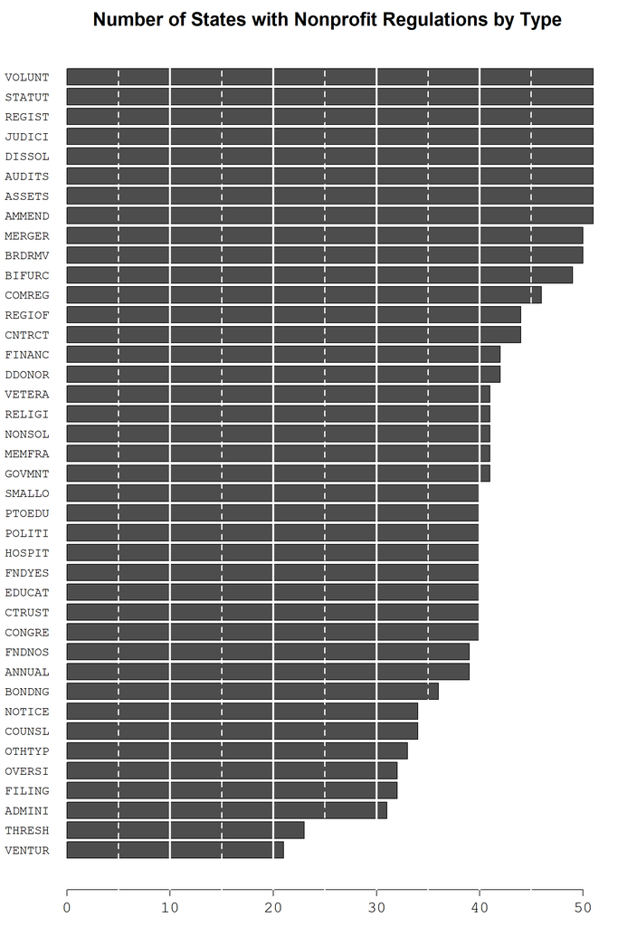

## State Environments

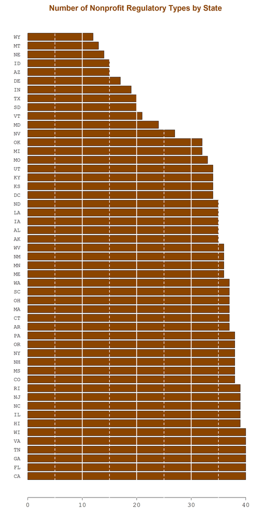

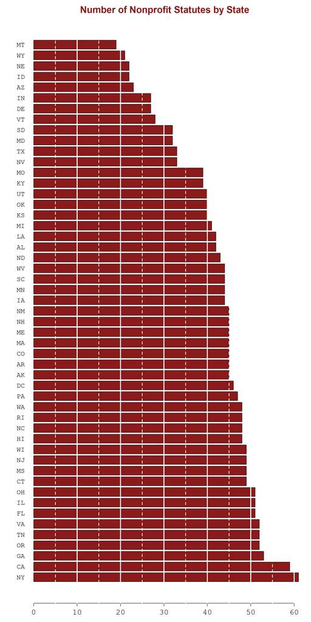

# Standardizing Citation Formats

Statutes are published in books called codes, which present laws for a particular jurisdiction arranged by subject.

Statute citations have a volume (federal) or state/municipality (local), the name of the cited code, a section, and a date:

Example: 42 U.S.C. § 7706(a) (1994). 42 = Volume that contains the statue U.S.C. = Abbreviation for the code 7706(a) = Section of the code being cited 1994 = Year the code volume was published

Universal Citation

A “media-neutral” or “vendor-neutral” citation. Generally, creating a citation to a legal source allows a reader to more efficiently locate it. The citation we provide here is one that is media-neutral and does not depend on being located in a print edition of a book.

This citation is based on the second edition of the American Association of Law Libraries “Universal Citation Guide”.

- Code State
- Code Label - name of the code publication (usually just “Code”)
- Are we citing the annotated version?
- Year
- Section1
- Section2 - end section if multiple sections listed
- Note (source, condition, exception)

For example:

- IA Code § 602.1614
- IA Code § 602.1614 - 602.1615
- IA Code § 602.1614 (Westlaw current through P.L. 116-193)

## EXAMPLES

### Abbreviations

Statutes are published in books called codes, which present laws for a particular jurisdiction arranged by subject.

In **most** cases there is one official “code book” (catalog of the current laws) that contains all of the individual statutes. Thus “statute” and “code” might be used interchangeably in citations or references (although technically the statute is a section within the code). Typically the **statute_ref** should be labeled as **CODE**.

- G.C. § 43-17-5 (georgia code)
- Ga ST § 14-3-1430 (georgia statutes?)
- **GA Code § 14-3-1430** *{universal}*

The exceptions is when states have specialized codes for specific agencies or if there are multiple jurisdictions or municipalities that might enforce a law, in which case the specific code must be noted:

- Cal. Prob. Code § 141. [PROBATE CODE]
- CA Corp Code (2023) § 15903.01 [CORPORATE CODE]
- Cincinnati, Ohio, Municipal Code § 302-5.
- Des Moines, Iowa, Municipal Code § 6.3.

### Code Names

In some states major divisions of the code are designated by name rather than by number. California, for example, has [28 different codes](https://leginfo.legislature.ca.gov/faces/codes.xhtml) corresponding to functional areas of the law.

- Business and Professions Code - BPC
- Civil Code - CIV
- Code of Civil Procedure - CCP
- Commercial Code - COM
- Corporations Code - CORP
- etc.

Thus “CA Code § 5830” is underspecified because it could mean either:

- CA WIC Code § 5830 (Welfare and Institutions Code)
- CA PRC Code § 5830 (Public Resources Code)

Kentucky uses “Revised Statutes” instead of “Code”:

- Ky. Rev. Stat. § 367.652
- KRS § 273.320

### Annotated Versions

Many codes are published in two editions – the official edition and an annotated edition with notes about related cases and articles.

- O.C.G.A. § 43-17-3 (official code of georgia annotated)
- Ga. Code Ann., § 14-3-1420
- **GA Code Annotated § 14-3-1430** *{universal}*

### Notes and Conditions

If the citation is taken from a source that requires citation, include a source field:

- IA Code (YEAR) § 602.1614 (Westlaw current through P.L. 116-193)

Should we cite the year before the Section Symbol instead of at the end to differentiate notes and sources from years, otherwise it would have double parentheses:

- IA Code § 602.1614 (YEAR) (Westlaw current through P.L. 116-193)

Do we need to add a condition or notes field as well?

- Ga. Code Ann., § 14-3-1041: only required if amending to operate for profit
- **GA Code Annotated § 14-3-1041 (only required if amending to operate for profit)**

### Multiple Sections Cited

If the referenced sections are adjacent then add an ending section:

AND:

- F.S.A. § 496.407(1)(b) and (c)
- **FL Statutes Annotated § 496.407(1)(b) - § 496.407(1)(c)** *{universal}*

OR;

- F.S.A. § 496.409; F.S.A. § 496.410
- **FL Code Annotated § 496.409 - § 496.410** *{universal}*

If not immediately adjacent they should be recorded as two separate rows in the data:

- Ga. Code Ann. § 14-3-1005; GA ST § 14-3-1007
- **GA Code Annotated § 14-3-1005** *{universal}*
- **GA Code Annotated § 14-3-1007** *{universal}*

## Years

If the provision being cited is currently in effect and has not been the subject of recent change, no date element need be included. However, if the provision being cited has, by the time of writing, been repealed or amended or if it has only recently been enacted or revised, the date of a compilation that contains the language cited should be provided in parentheses.

- Iowa Code (2020) § 1606(1)(a)
- Iowa Code (2012) § 1606(1)(a) (prior to 2013 amendment)
- Iowa Code (2012) § 1606(1)(a) (eff. 7/1/2013)

Unless the citation’s context furnishes the information, a parenthetical note identifying the amending legislation and clarifying whether the citation refers to the version in effect before or after the change may be called for. The precise form this information takes will be governed by the form in which the compilation relied upon presents its “as of” date.

- GA ST § 14-3-1430 (Amended by 2023 Ga. Laws 260,§ 1-1, eff. 7/1/2023)
- **GA Code (2023) § 14-3-1430** *{universal}*

Need to add a field to capture the bill that changed the law?

- **change field: Amended by 2023 Ga. Laws 260,§ 1-1**

## Time and Revision Fields

### Example

[GA Code § 33-24-47.1 (2023)](https://law.justia.com/codes/georgia/title-33/chapter-24/article-1/section-33-24-47-1/)

Note that “article” is not a part of the citation.

**Justia dot com Representation:**

```
2023 CODE OF GEORGIA:

Title 33         - INSURANCE (§§ 33-1-1 — 33-66-8)
Chapter 24       - INSURANCE GENERALLY (§§ 33-24-1 — 33-24-98)
Article 1        - GENERAL PROVISIONS (§§ 33-24-1 — 33-24-59.33)
Section 33-24-47 - Notice required of termination or nonrenewal, increase in premium rates, or change restricting or reducing coverage; failure of insurer to comply
```

**The URL Structed Similarly:**

```
https://law.justia.com/codes/georgia/title-33/chapter-24/article-1/section-33-24-47-1/
```

How to determine which of these updates impacted this specific law?

Also, is this a legislative reference (ID and section of the bill), not a legal reference (ID and section of the code that the bill changed): 2019 Ga. Laws 140,§ 52?

**Justia dot com:**

```
GA Code § 33-24-47.1 (2023)

Amended by 2019 Ga. Laws 140,§ 52, eff. 7/1/2019.

Amended by 2015 Ga. Laws 9,§ 33, eff. 3/13/2015.
```

## Time Fields

### Types of Change

- new law
- major change (substantive meaning change)
- minor change (minor edits to clarify intent)
- interpretive change (section not changed, but other changes impact)
- repeal of a law

Note that a repeal would appear as a new row if it is not replaced by another law:

- GA Code (2015) § 33-24-47
- GA Code (2022) § 33-24-47 (repealed)

The second entry designates a repeal of the 2015 law, the repeal passing in 2022.